# Thema 3 · Normaalverdeling & *z*-scores

Deel 2 — Standaardiseren · *ruw is ruk, het lineaaltje*

# Ruw is ruk

Een egel scoort 130 op pienterheid. Is dat veel? Je hebt geen idee. Honderddertig wát? Een ruwe score op zichzelf zegt **niks** — je weet niet waar het midden ligt, niet hoe uitgesmeerd de groep is, niet of 130 zeldzaam is of doodgewoon.

Daarom: **ruw is ruk.** We willen een score die zichzelf uitlegt. Dat is een **z-score**.

**OpmerkingDe egels — pienterheid**

De pienterheid van de egels is **normaal verdeeld** met gemiddelde $\mu_x = 100$ en standaardafwijking $\sigma_x = 15$. (Een schaal zoals IQ.) Dat houden we dit thema aan.

# Het marsmannetje

Stel je praat met een marsmannetje. Het kent de aarde niet, maar rekenen kan het wel. Je zegt: “mijn pienterheid is 130.” Daar heeft het niks aan — 130 betekent niks op Mars.

Wat heeft het marsmannetje wél nodig? Precies twee dingen:

1. **“Het is normaal verdeeld”** — dan ziet het de bekende belcurve voor zich.
2. **“Ik zit 2 standaardafwijkingen rechts van het midden.”**

Meer niet. Niet de 130, niet de 100, niet de 15 — die zijn allemaal *ruk*. Het enige dat telt is **hoeveel standaardafwijkingen** je van het midden zit. En dát getal is de z-score.

# *z* = het aantal lineaaltjes

Denk aan de standaardafwijking als een **lineaaltje** van 15 punten. De z-score is simpelweg: *hoe vaak past dat lineaaltje tussen het midden en jouw score?*

$$z = \frac{x - \mu_x}{\sigma_x} = \frac{\text{specifiek} - \text{algemeen}}{\text{lineaaltje}}$$

Voor onze egel van 130: $z = \dfrac{130 - 100}{15} = 2$. Twee lineaaltjes naar rechts. Twee wát? Twee koeien, twee moeders? Nee — **twee standaardafwijkingen**. Zet er altijd de tel-eenheid bij.

**Tipz heeft altijd dezelfde eigenschappen**

Stel je standaardiseert een hele groep, dan geldt **altijd**: $\mu_z = 0$ (het midden wordt 0) en $\sigma_z = 1$ (het lineaaltje wordt precies 1 lang). Wat níét altijd geldt: dat z normaal verdeeld is — z heeft dezelfde *vorm* als $x$. Is $x$ scheef, dan is z ook scheef. Standaardiseren verschuift en schaalt; het maakt niks recht.

# De normaalverdeling

Waar komt die belcurve vandaan? Denk aan een houten plank vol spijkers, rechtop gezet. Je laat boven in het midden een knikker vallen: tik-tik-tik stuitert hij tussen de spijkers naar beneden. Meestal landt hij rond het midden, soms wat extremer. Doe dat met duizend knikkers en je krijgt vanzelf die gladde bel.

Notatie: $x \sim N(\mu, \sigma)$ — het krulletje betekent “gedraagt zich als”, de $N$ staat voor normaal. Onze egels: pienterheid $\sim N(100, 15)$ — lees dit als: *normaal verdeeld met gemiddelde 100 en standaardafwijking 15*.

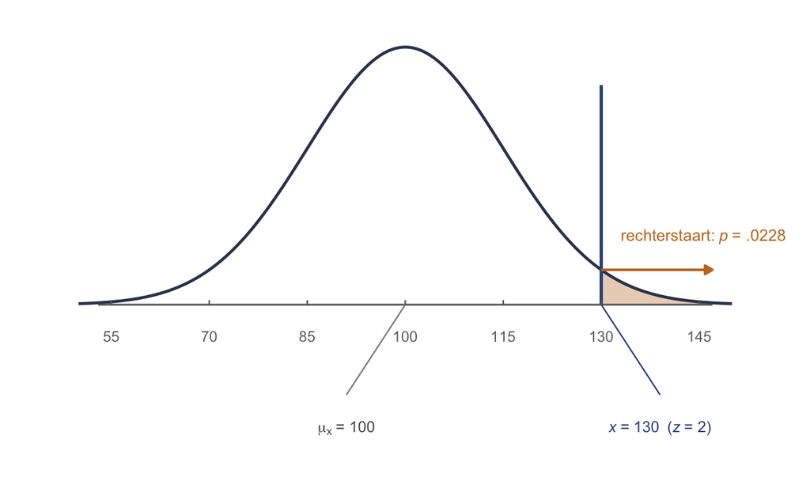

Figuur 1: Egel-pienterheid ~ N(100, 15). Onze egel met score 130 (z = 2) staat als blauwe streep getekend; de oranje staart rechts daarvan is het gebied ‘minstens zo extreem’ — bij z = 2 is dat p = .0228 (zo’n 2,3%). Dit is precies de wandeling x → z → p van de richtings-engine.

**TipDe 68–95–99,7-regel**

Bij een normaalverdeling ligt **68%** binnen één lineaaltje van het midden ($\mu_x \pm \sigma_x$), **95%** binnen twee, en **99,7%** binnen drie. Voor de egels: tussen 85 en 115 zit zo’n 68% van de pienterheid.

# De *z*-tabel

De z-tabel (Tabel A, de standaardnormaal) vertaalt een z-score naar een **kans**. Twee regels die je leven redden:

- **Regel 1: téken eerst.** Schets de bel, zet je z erin, arceer het stuk dat je zoekt. Kijk: heb je een twee- of een driedeling nodig? Welke staart?
- De tabel geeft **altijd de linkerkant** (de kans op “of lager”). Wil je de rechterstaart, doe dan 1 min de tabelwaarde — of zoek de negatieve z op, want door de symmetrie is dat hetzelfde.

De tabel verkeerd *aflezen* is zelden het probleem; het verkeerde *gebied* arceren wél. Daarom: eerst tekenen, dán pas opzoeken.

**TipHeilige z-waarden (uit je hoofd)**

| Eén staart | z* | Midden (tweezijdig) |
| --- | --- | --- |
| 5% | **1,645** | 90% |
| 2,5% | **1,96** | 95% |
| 0,5% | **2,576** | 99% |

De **1,96** is de heiligste — maar let op: die hoort bij 2,5% in één staart (95% in het *midden*), níét bij 5% in één staart. Voor 5% in één staart is het **1,645**. Teken het, dan zie je het verschil.

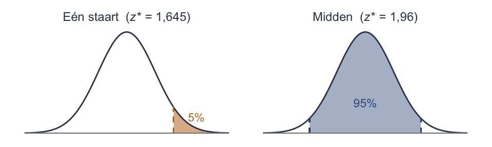

Figuur 2: Links de **tweedeling** — 5% in één (rechter)staart hoort bij $z^*$ = 1,645. Rechts de **driedeling** — 95% in het midden (dus 2,5% per staart) hoort bij $z^*$ = 1,96. Zelfde 95%-gevoel, andere knip: dáár zit het verschil.

# De richtings-engine: *x* ⇄ *z* ⇄ *p*

Bijna alles wat hierna komt — z-scores, betrouwbaarheidsintervallen, toetsen, power — is dezelfde wandeling, twee kanten op. Eén ketting:

$$\text{gebeurtenis } x \;\rightleftarrows\; \text{aantal lineaaltjes } z \;\rightleftarrows\; \text{kans } p$$

- **$x \to z$:** “hoe ver van het midden, in lineaaltjes?” → $z = \dfrac{x - \mu_x}{\sigma_x}$.
- **$z \to x$:** “loop $z$ lineaaltjes vanaf het midden” → $x = \mu_x + z \cdot \sigma_x$.
- **$z \rightleftarrows p$:** de z-tabel, heen of terug.

**De gegeven bepaalt de richting.** Krijg je een score en zoek je een kans? Dan ga je $x \to z \to p$. Krijg je een kans (of percentage) en zoek je een score? Dan $p \to z \to x$. Lees dus eerst: wat is gegeven, en wat moet ik hebben?

**TipHet fietsje**

Zie het als fietsen. Je huis (het midden) staat op $\mu_x$. Je snelheid is het lineaaltje, $\sigma_x$ per “uur”. Twee uur fietsen naar rechts? Dan ben je op $\mu_x + 2\cdot\sigma_x$. Of andersom: “hoe lang moet ik fietsen om bij score 130 te komen?” → $(130-100)/15 = 2$ uur. Wie dit ziet, heeft straks **geen losse formules meer nodig** — het is steeds ditzelfde fietsje, alleen met een ander lineaaltje.

# Twee soorten vragen

## Gewoon: $x \to z \to p$ (score gegeven, kans gezocht)

*Welk deel van de egels is pienterder dan 130?*

1. $z = \dfrac{130 - 100}{15} = 2{,}00$ (twee lineaaltjes rechts).
2. Tabel A bij $z = 2{,}00$: linkerkant $= .9772$.
3. We willen de rechterstaart: $1 - .9772 = .0228$.

Dus **2,28%** van de egels is pienterder dan 130. (Teken het: een klein staartje rechts — klein staartje = extreem.)

| $i$ | egel | $x_i$ | $z_i = \dfrac{x_i-100}{15}$ | rechterstaart |
| --- | --- | --- | --- | --- |
| 1 | A | 130 | +2,00 | .023 |
| 2 | B | 92,5 | −0,50 | .691 |
| 3 | C | 115 | +1,00 | .159 |

## Invers: $p \to z \to x$ (kans gegeven, score gezocht)

*Boven welke pienterheid zitten de 10% slimste egels?*

1. 10% boven → 90% eronder → in de tabel hoort daar $z \approx 1{,}28$ bij.
2. Loop terug: $x = \mu_x + z\cdot\sigma_x = 100 + 1{,}28 \cdot 15 = 119{,}2$.

Dus vanaf zo’n **119** behoor je tot de slimste 10%. Zelfde fietsje, andere kant op.

**OpmerkingIn SPSS — klikpad**

Het lineaaltjes-rekenwerk hoeft niet met de hand: SPSS standaardiseert een hele kolom in één klik.

**Analyze → Descriptive Statistics → Descriptives** → variabele naar rechts → vink *Save standardized values as variables* aan → *OK*.

Je krijgt een nieuwe kolom `Z`*variabele* in de dataset: dat zijn precies de z-scores. De stap z → p (de kans) doe je daarna nog steeds zelf met de tabel — tekenen blijft.

# Oefenen

**OpmerkingT3.1 — Het marsmannetje**

Een uil heeft een nachtelijke-alertheidsscore van 70, op een schaal die normaal verdeeld is met $\mu_x = 50$ en $\sigma_x = 10$.

1. Wat is de z-score?
2. Welk deel van de uilen is alerter?
3. Wat zou je het marsmannetje vertellen — in twee zinnen, zonder de ruwe score?

**OpgeletAntwoord T3.1**

**(a)** $z = \dfrac{70 - 50}{10} = 2{,}00$ — twee lineaaltjes rechts.

**(b)** Tabel A bij $z=2{,}00$: links $.9772$ → rechterstaart $1 - .9772 = .0228$ → **2,28%** is alerter.

**(c)** “Mijn score is normaal verdeeld, en ik zit twee standaardafwijkingen boven het gemiddelde” — oftewel: maar zo’n 2% is alerter dan ik.

**OpmerkingT3.2 — Invers**

Bij diezelfde uilen ($\mu_x = 50$, $\sigma_x = 10$): onder welke alertheidsscore zitten de **25% minst alerte** uilen?

**OpgeletAntwoord T3.2**

25% in de linkerstaart → in de tabel hoort daar $z \approx -0{,}674$ bij (negatief, want links van het midden). Terugfietsen: $x = 50 + (-0{,}674)\cdot 10 = 43{,}3$. Onder ongeveer **43** zitten de 25% minst alerte uilen. *(Herken je dit? Het is precies de p→z→x-vraag waarmee we straks de kritieke waarde van een toets gaan vinden.)*

# Wat blijft liggen

Tot nu toe standaardiseren we de score van één **individu** — het lineaaltje is dan $\sigma_x$. Straks (Deel 4) kijken we niet naar één egel maar naar een heel **steekproefgemiddelde**; dan wordt het lineaaltje de standaardfout $\sigma_{\bar{x}} = \sigma_x/\sqrt{n}$. De wandeling x ⇄ z ⇄ p blijft exact hetzelfde — alleen het lineaaltje verandert.

# Tot slot

Een ruwe score is ruk; een z-score legt zichzelf uit. Onthoud het lineaaltje en het fietsje — want vanaf hier is élke toets, élk interval en straks de power niets anders dan deze ene wandeling, twee kanten op.

*Werkboek OZP 1 · Thema 3, versie 0.1 (handrekenen & theorie; SPSS later). Doorlopend voorbeeld: de egels.*

Terug naar boven